# Depression Classification Project

2025-12-17

## How Well Can We Classify Student Depression?

- **Data Set**

Student Depression Dataset

- **Data**

Almost 28,000 student records with various academic, financial, and lifestyle predictors

- **Goal**

Classify student depression risk with high accuracy and interpretability

- **Methods Used**

Logistic Regression, K Nearest Neighbors, Lasso and Random Forest

## Specificities

**Categories:**

## Example Plots

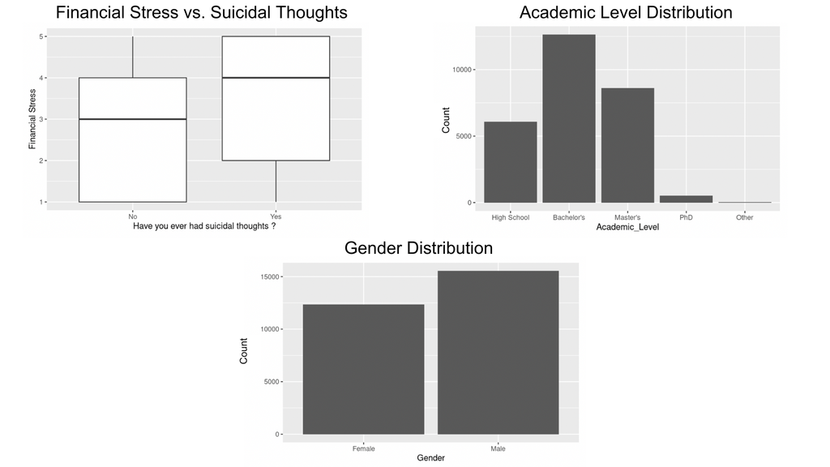

## Leah - Logistic Regression

- **Approach**
  - Created 16 logistic regression models, starting with a single predictor and slowly adding more
- **Details**
  - Converted all categorical predictors into factors
  - Created a list of formulas for the various models - 16 models total, 13 adding predictors individually and 3 with interaction terms based on intuition
  - Used a loop to fit each model with formulas
- **Motivation for Approach**
  - Comparing model complexity between various predictors and measure predictive accuracy compared to another types of models

## Leah - 5-Fold Cross Validation Results

- **Details**
  - Group landed on each trying 5-fold cross validation for each of the models to compare accurately
  - Using model, predicted depression status and compared to actual depression status
  - Calculated accuracy for each of the models
  - Averaged model performance across folds
- **Top Performing Models**
  1. **All 13 predictors, no interaction terms** - Accuracy: **84.791%**
  2. **All 13 predictors + Interaction of Family History of Mental Illness x Have you ever had suicidal thoughts?** - Accuracy: **84.784%**
  3. **All 13 predictors + Interaction of Sleep Duration x Work/Study Hours** - Accuracy: **84.780%**
- **Conclusion**
  - Best performing model was one with no interactions, and although adding they came close in terms of accuracy, they did not improve it much.

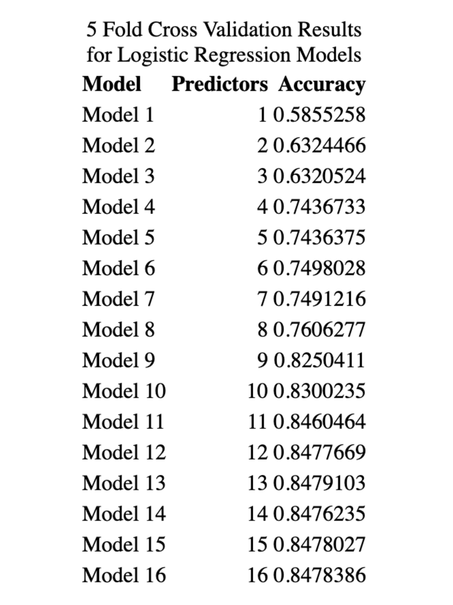

Logistic Regression Test Set Accuracy: 0.8435484

## The Results - Tanner

Key Takeaways

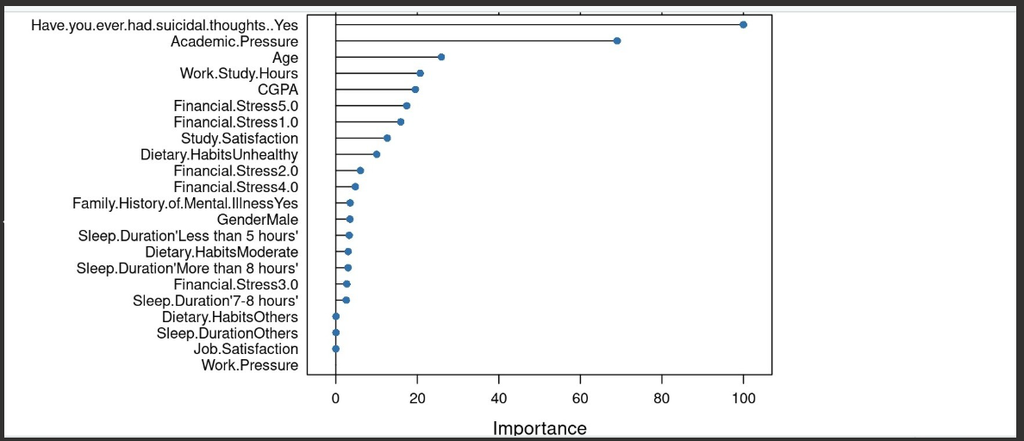

## K-nearest neighbors

**Why KNN**

K-nearest neighbors is a supervised classification method

- Binary outcome (depressed (1) vs not depressed (0))
- Continuous predictors
- KNN is non-parametric

## CV

**One important choice in KNN is k**

- if k is too small the model is noisy
- if k is too big it is too smooth

So, we tried two standard values k = 5 vs k = 10 For the accuracy check we used 5 - fold cross-validation.

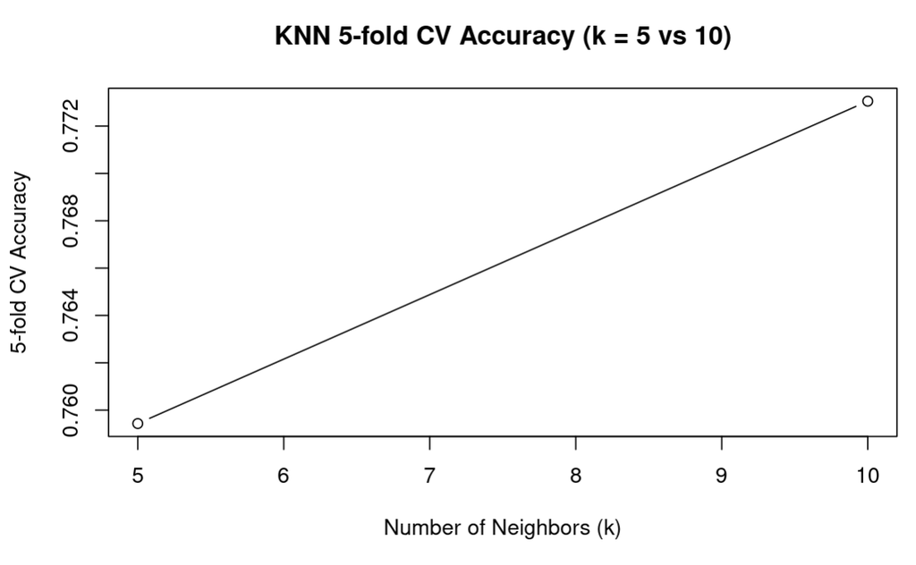

## k = 5 gives about 0.759 accuracy, k = 10 gives about 0.773. Since k = 10 is slightly better, we chose k = 10 for our final KNN model.

## Confusion matrix

The CV accuracy doesn’t report how many mistakes the model made. To see that we use confusion matrix

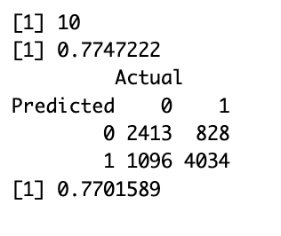

**On our test set we had 8,371 students**

- 2,413 of 3,509 non-depressed students were correctly classified as ‘no depression’
- 4,034 of 4,862 depressed students were correctly classified as ‘depression’
- 828 depressed students were missed (model said ‘no depression’).
- 1,096 non-depressed students were false alarms (model said ‘depression’)

Overall, it gives us approximately 77% of accuracy

## KNN numerical + categorical

After that, we also let KNN use the categorical information

- we added categorical variable
- turned these into dummy variables
- used 5 fold cross-validation

## CV

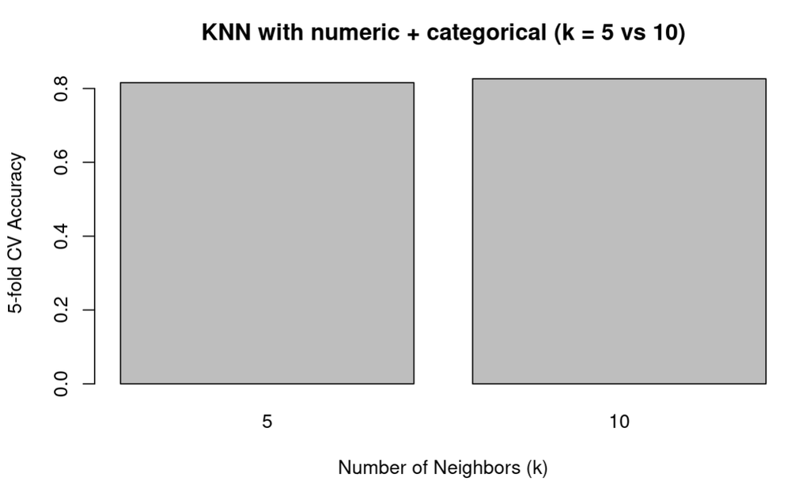

- k = 10 again performs better than k = 5
- The best cross-validated accuracy is now about 0.83, which is higher than the 0.77 we had with numeric predictors only

## Confusion matrix

To see what this means in terms of individual students, we again look at the confusion matrix for k = 10:

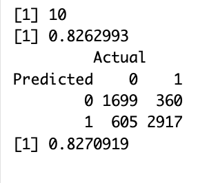

Test set accuracy: 82.7%

## Interpretation

**Total students in this test set: 5,581**

- 1,699 of 2,304 non-depressed students were correctly predicted as 0
- 2,917 of 3,277 depressed students were correctly predicted as 1
- 360 depressed students were missed (predicted as 0 instead of 1)
- 605 non-depressed students were false alarms (predicted as 1 instead of 0)

Overall, KNN with numeric + categorical predictors reaches about 82–83% accuracy, so including these categorical variables makes the model more accurate than using only numeric predictors

## LASSO-Regularized Logistic Regression

**Why Lasso:**

- Addressing overfitting and difficult interpretation due to the large number of predictors (high dimensionality).
- Essentially, it is Logistic Regression with an added L1 regularization penalty.

\[\text{Minimize} \left( \text{Negative Log-Likelihood} + \lambda \sum_{j=1}^{p} |\beta_j| \right)\]

**How Lasso Was Prepared**

- Transformed all categorical features into numeric dummy variables.
- Standardized all numeric predictors so the Lasso penalty (\(\lambda\)) treats them equally.
- Tuned the penalty parameter (\(\lambda\)): Performed 5-fold CV across 30 levels of \(\lambda\) to find the optimal sparsity/fit trade-off.

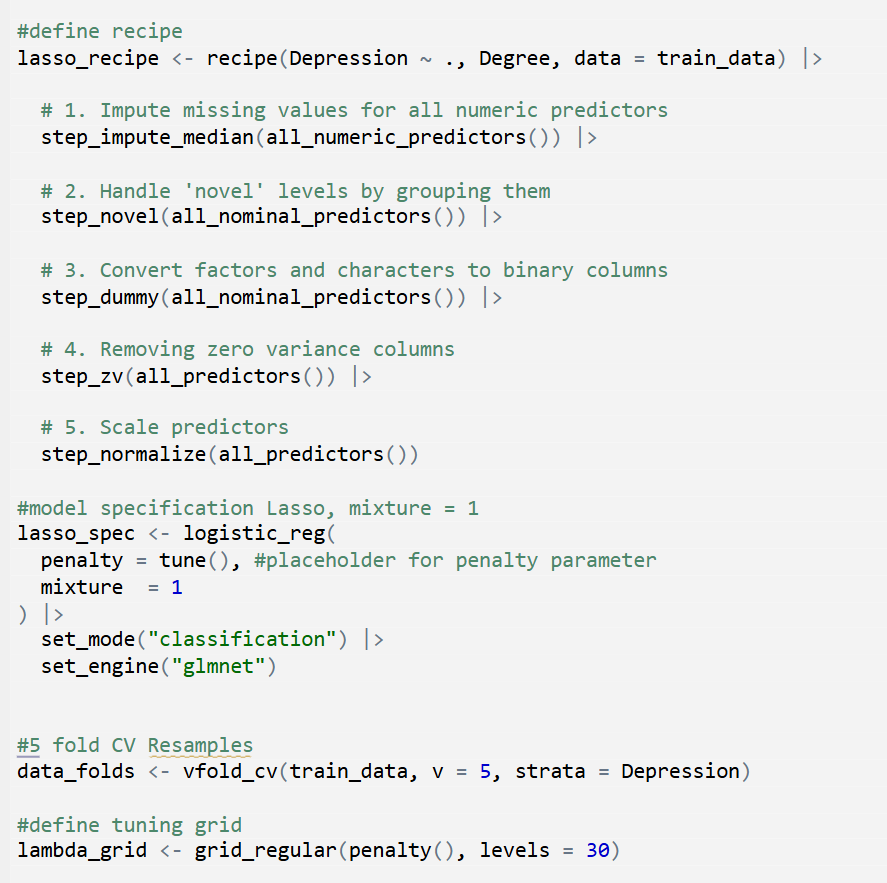

**Lasso Sparsity and Interpretability**

- Optimal \(\lambda\) Value Chosen: The final \(\lambda\) of \(.00174\) was chosen to maximize cross-validated performance.
- Feature Selection: The model set 27 coefficients to zero (out of 67 total predictors) and resulted in a sparse final model with 40 relevant features.
- Key Interpretive Takeaways (from Non-Zero Coefficients):
- For every standard deviation increase in Academic Pressure, the odds of a student experiencing depression increase by over \(\mathbf{200\%}\) (a factor of \(3.03\)).
- For every one standard deviation increase in Study Satisfaction, the odds of experiencing depression decrease by about \(25.8\%\) (a factor of \(0.74\)).

**Lasso Test Set Performance**

- Test Set Accuracy: 85.09%
- Confusion Matrix

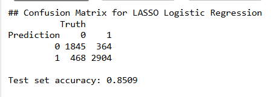

**Total students in this test set: 5,581**

## Slide 5: Conclusion

- We compared Test Set Accuracy because it measures performance on completely unseen data, providing the most unbiased estimate of real-world model effectiveness.
- Test set accuracy
- Tanner RF: 83.35%
- Juliette Lasso: **85%**
- Munisa KNN: 82.7%
- Leah Logistic Regression (model 13): 84.35%

Best Test set accuracy: Lasso

## Takeaways

- The LASSO’s **L1 regularization penalty was highly effective** , leading it to outperform the simpler, unregularized Logistic Regression (85.00% vs. 84.35%)
- Lasso also outperformed the complex, harder-to-interpret models (RF and KNN).
- This demonstrates that **sparsity and simplicity** , along with a **linear structure** , are the ideal fit for classifying student depression risk in this dataset.
- Academic Pressure is the Primary Driver: The strongest factor driving depression risk is Academic Pressure. (The LASSO model confirmed that for every one standard deviation increase in Academic Pressure, the odds of a student experiencing depression increase by over \(200\%\) (a factor of \(3.03\)).)